# ABCDv5.1 Baseline Scores

# Elastic net linear regression using ‘glmnet’

Predictors identified from quantitative reviews of adolescent MDD risk factors in baseline ABCD data are included in the model, along with interactions with gender (parent-reported child gender identity). I will also fit a model with interactions with birth sex too as a sensitivity analysis.

80-20 training-test split. Training sample N=6046, test sample N=1537. Although glmnet standardises data by default, coefficients are returned on their original scales. To get standardised coefficients for applying to other data, I’m scaling the raw data before inputting to glmnet. Each elastic net model is run with 10-fold cross-validation and lambda values are selected based on minimising the model mean squared error (MSE).

# CBCL DSM5-oriented depression subscale

## Lambda plot

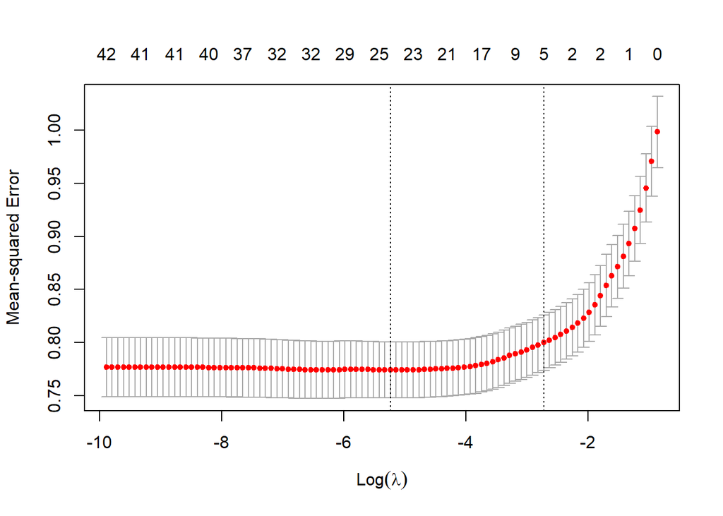

## Fit statistics

| Sample | Lambda | MSE | RMSE | MAE |
| --- | --- | --- | --- | --- |
| training | min | 0.766 | 0.875 | 0.598 |
| training | 1se | 0.798 | 0.893 | 0.615 |
| test | min | 0.782 | 0.884 | 0.590 |
| test | 1se | 0.782 | 0.884 | 0.590 |

## Plot predictions

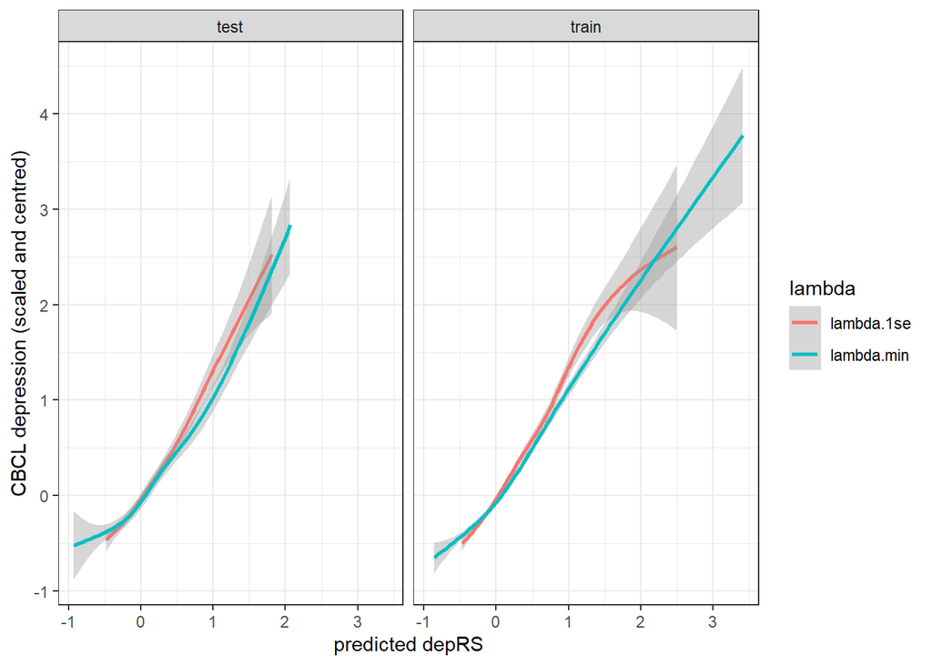

# CBCL internalising subscale

## Lambda plot

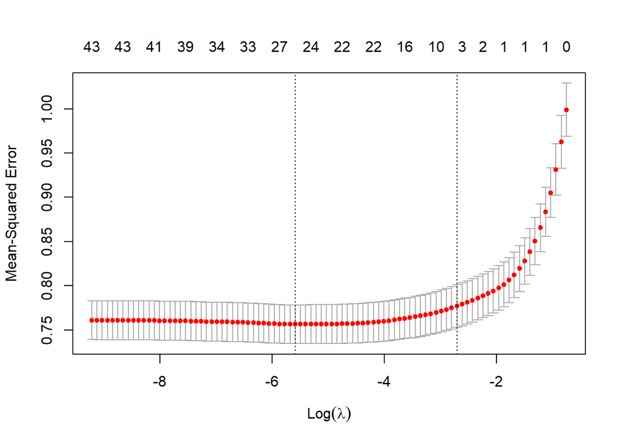

## Fit statistics

| Sample | Lambda | MSE | RMSE | MAE |
| --- | --- | --- | --- | --- |
| training | min | 0.746 | 0.864 | 0.627 |
| training | 1se | 0.775 | 0.880 | 0.640 |
| test | min | 0.800 | 0.894 | 0.595 |
| test | 1se | 0.800 | 0.894 | 0.595 |

## Plot predictions

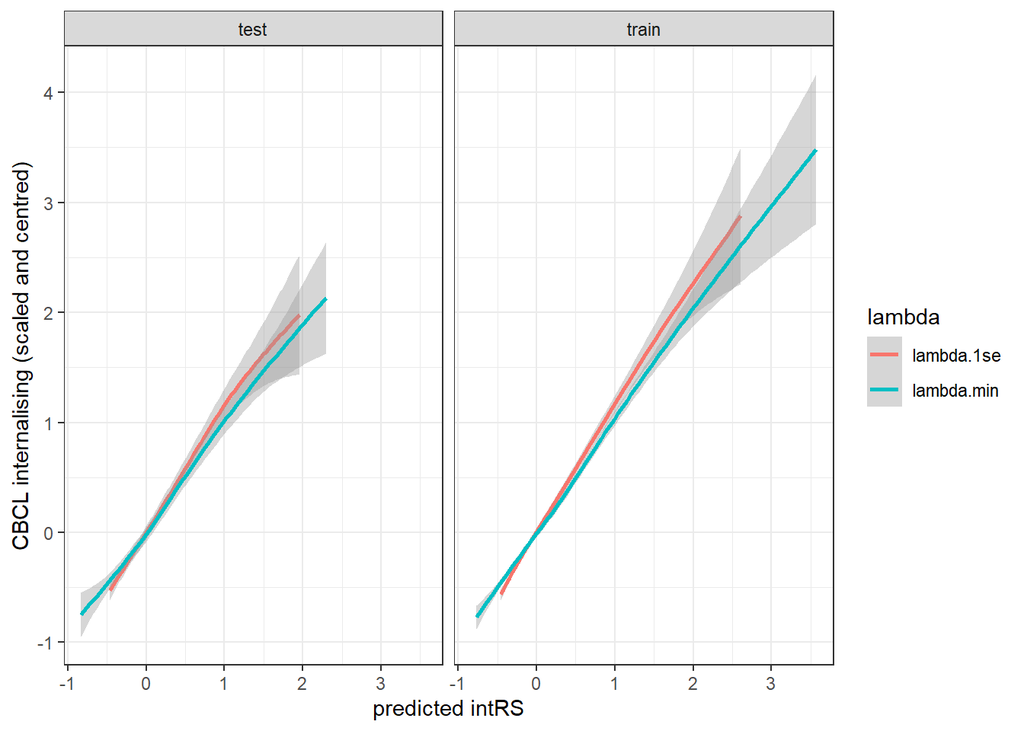

# Coefficients

beta.min = coefficients for lambda value that produces minimum mean cross-validated error beta.1se = coefficients for lambda value that produces the most regularized model while keeping the cross-validated error within one standard error of the minimum.

| predictor | dep_beta.min | dep_beta.1se | int_beta.min | int_beta.1se |
| --- | --- | --- | --- | --- |
| (Intercept) | -2.002 | -0.332 | -1.871 | -0.159 |
| tobacco_puff | 0.088 | 0.000 | 0.267 | 0.000 |
| weightcontrol_ksads | 0.326 | 0.014 | 0.308 | 0.002 |
| witness_comm_violence | 0.000 | 0.000 | -0.061 | 0.000 |
| death_loved_one | 0.070 | 0.000 | 0.094 | 0.000 |
| witness_dv | 0.164 | 0.081 | 0.213 | 0.123 |
| s_abuse | 0.088 | 0.000 | 0.104 | 0.000 |
| p_abuse | 0.412 | 0.000 | 0.247 | 0.000 |
| emot_abuse | 0.274 | 0.000 | 0.225 | 0.000 |
| serious_accident | 0.088 | 0.000 | 0.116 | 0.000 |
| sleep_hrs | 0.190 | 0.136 | 0.065 | 0.013 |
| bmi | -0.004 | 0.000 | 0.000 | 0.000 |
| needed_food | 0.141 | 0.000 | 0.104 | 0.000 |
| income | 0.000 | 0.000 | 0.000 | 0.000 |
| parent_ed | 0.020 | 0.000 | 0.000 | 0.000 |
| gender | 0.000 | 0.000 | 0.000 | 0.000 |
| area_depriv | -0.022 | 0.000 | -0.031 | 0.000 |
| comm_safety | -0.014 | 0.000 | -0.030 | 0.000 |
| days_active | 0.000 | 0.000 | -0.012 | 0.000 |
| fam_conflict | 0.041 | 0.004 | 0.000 | 0.000 |
| p_monitoring | -0.034 | 0.000 | -0.035 | 0.000 |
| p_depression | 0.367 | 0.338 | 0.399 | 0.398 |
| agemths | 0.010 | 0.000 | 0.000 | 0.000 |
| tobacco_puff_gender | 0.000 | 0.000 | 0.000 | 0.000 |
| weightcontrol_ksads_gender | 0.000 | 0.000 | 0.007 | 0.000 |
| witness_comm_violence_gender | 0.000 | 0.000 | 0.000 | 0.000 |
| death_loved_one_gender | 0.000 | 0.000 | 0.000 | 0.000 |
| witness_dv_gender | 0.000 | 0.000 | 0.000 | 0.000 |
| s_abuse_gender | 0.000 | 0.000 | 0.000 | 0.000 |
| p_abuse_gender | 0.000 | 0.000 | 0.000 | 0.000 |
| emot_abuse_gender | -0.064 | 0.000 | 0.000 | 0.000 |
| serious_accident_gender | 0.000 | 0.000 | 0.000 | 0.000 |
| sleep_hrs_gender | 0.000 | 0.000 | 0.000 | 0.000 |
| bmi_gender | 0.000 | 0.000 | 0.000 | 0.000 |
| needed_food_gender | 0.000 | 0.000 | 0.000 | 0.000 |
| income_gender | 0.000 | 0.000 | 0.001 | 0.000 |
| parent_ed_gender | 0.000 | 0.000 | 0.015 | 0.000 |
| area_depriv_gender | -0.033 | 0.000 | -0.012 | 0.000 |
| comm_safety_gender | -0.013 | 0.000 | -0.011 | 0.000 |
| days_active_gender | -0.015 | 0.000 | 0.000 | 0.000 |
| fam_conflict_gender | 0.001 | 0.000 | 0.024 | 0.000 |
| p_monitoring_gender | 0.000 | 0.000 | 0.000 | 0.000 |
| p_depression_gender | 0.000 | 0.000 | 0.019 | 0.000 |
| agemths_gender | 0.000 | 0.000 | 0.005 | 0.000 |

## beta.min

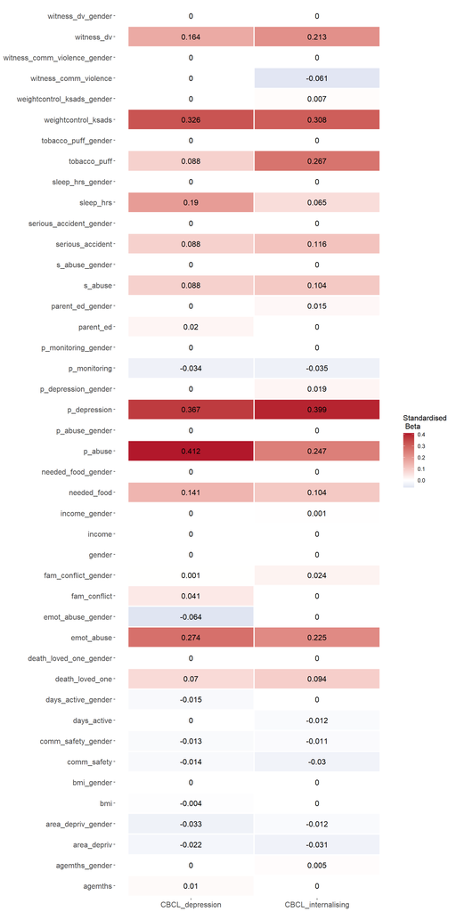

## beta.1se

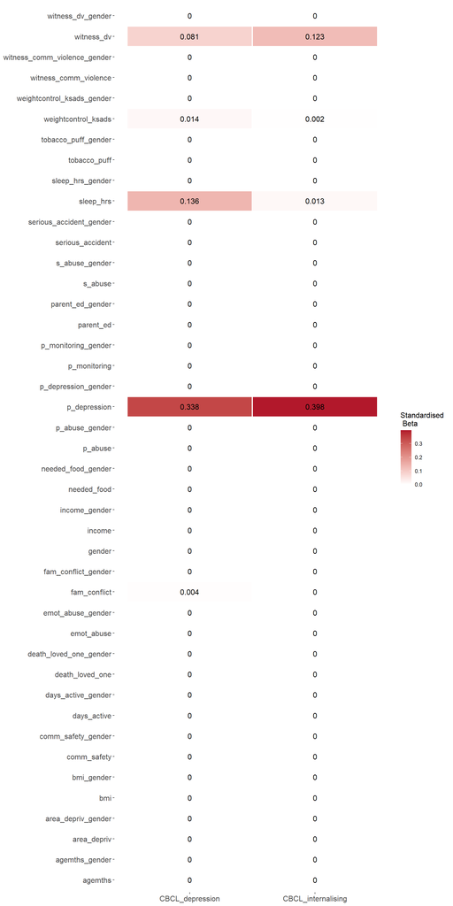

# Non-zero coefficients

## beta.min

### CBCL depression

|  | preds | beta.min | beta.1se | out |
| --- | --- | --- | --- | --- |
| 81 | p_abuse | 0.412 | 0.000 | CBCL_depression |
| 221 | p_depression | 0.367 | 0.338 | CBCL_depression |
| 310 | weightcontrol_ksads | 0.326 | 0.014 | CBCL_depression |
| 91 | emot_abuse | 0.274 | 0.000 | CBCL_depression |
| 111 | sleep_hrs | 0.190 | 0.136 | CBCL_depression |
| 61 | witness_dv | 0.164 | 0.081 | CBCL_depression |
| 131 | needed_food | 0.141 | 0.000 | CBCL_depression |
| 210 | tobacco_puff | 0.088 | 0.000 | CBCL_depression |
| 101 | serious_accident | 0.088 | 0.000 | CBCL_depression |
| 71 | s_abuse | 0.088 | 0.000 | CBCL_depression |
| 51 | death_loved_one | 0.070 | 0.000 | CBCL_depression |
| 201 | fam_conflict | 0.041 | 0.004 | CBCL_depression |
| 151 | parent_ed | 0.020 | 0.000 | CBCL_depression |
| 231 | agemths | 0.010 | 0.000 | CBCL_depression |
| 411 | fam_conflict_gender | 0.001 | 0.000 | CBCL_depression |
| 121 | bmi | -0.004 | 0.000 | CBCL_depression |
| 391 | comm_safety_gender | -0.013 | 0.000 | CBCL_depression |
| 181 | comm_safety | -0.014 | 0.000 | CBCL_depression |
| 401 | days_active_gender | -0.015 | 0.000 | CBCL_depression |
| 171 | area_depriv | -0.022 | 0.000 | CBCL_depression |
| 381 | area_depriv_gender | -0.033 | 0.000 | CBCL_depression |
| 211 | p_monitoring | -0.034 | 0.000 | CBCL_depression |
| 311 | emot_abuse_gender | -0.064 | 0.000 | CBCL_depression |

### CBCL internalising

|  | preds | beta.min | beta.1se | out |
| --- | --- | --- | --- | --- |
| 22 | p_depression | 0.399 | 0.398 | CBCL_internalising |
| 3 | weightcontrol_ksads | 0.308 | 0.002 | CBCL_internalising |
| 2 | tobacco_puff | 0.267 | 0.000 | CBCL_internalising |
| 8 | p_abuse | 0.247 | 0.000 | CBCL_internalising |
| 9 | emot_abuse | 0.225 | 0.000 | CBCL_internalising |
| 6 | witness_dv | 0.213 | 0.123 | CBCL_internalising |
| 10 | serious_accident | 0.116 | 0.000 | CBCL_internalising |
| 7 | s_abuse | 0.104 | 0.000 | CBCL_internalising |
| 13 | needed_food | 0.104 | 0.000 | CBCL_internalising |
| 5 | death_loved_one | 0.094 | 0.000 | CBCL_internalising |
| 11 | sleep_hrs | 0.065 | 0.013 | CBCL_internalising |
| 41 | fam_conflict_gender | 0.024 | 0.000 | CBCL_internalising |
| 43 | p_depression_gender | 0.019 | 0.000 | CBCL_internalising |
| 37 | parent_ed_gender | 0.015 | 0.000 | CBCL_internalising |
| 25 | weightcontrol_ksads_gender | 0.007 | 0.000 | CBCL_internalising |
| 44 | agemths_gender | 0.005 | 0.000 | CBCL_internalising |
| 36 | income_gender | 0.001 | 0.000 | CBCL_internalising |
| 39 | comm_safety_gender | -0.011 | 0.000 | CBCL_internalising |
| 38 | area_depriv_gender | -0.012 | 0.000 | CBCL_internalising |
| 19 | days_active | -0.012 | 0.000 | CBCL_internalising |
| 18 | comm_safety | -0.030 | 0.000 | CBCL_internalising |
| 17 | area_depriv | -0.031 | 0.000 | CBCL_internalising |
| 21 | p_monitoring | -0.035 | 0.000 | CBCL_internalising |
| 4 | witness_comm_violence | -0.061 | 0.000 | CBCL_internalising |

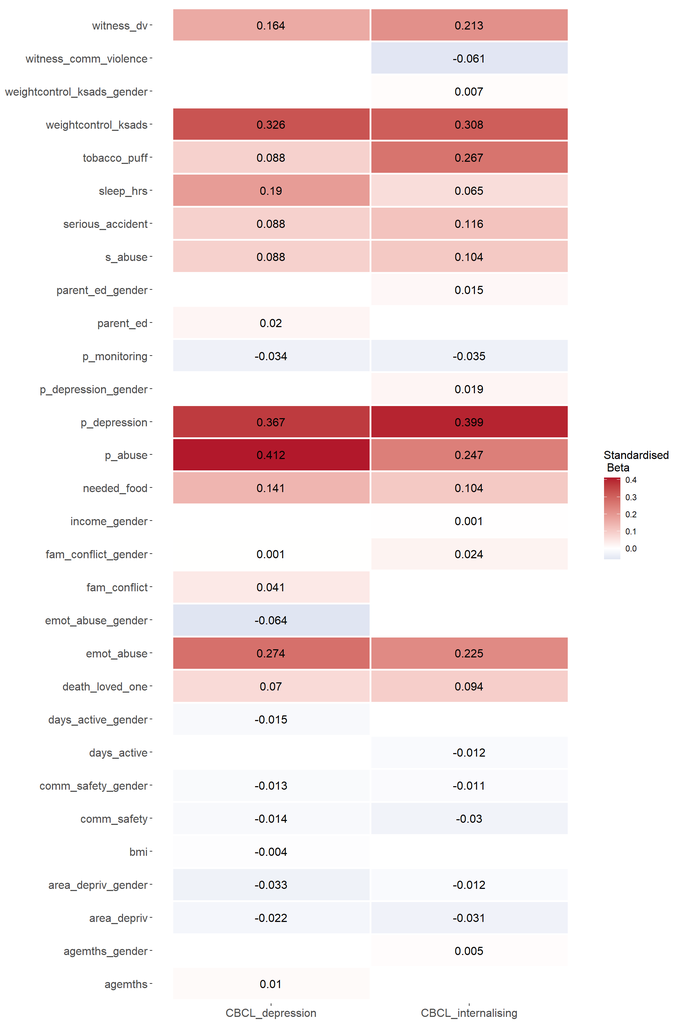

## beta.min > 0.01

### CBCL depression

|  | preds | beta.min | beta.1se | out |
| --- | --- | --- | --- | --- |
| 81 | p_abuse | 0.412 | 0.000 | CBCL_depression |
| 221 | p_depression | 0.367 | 0.338 | CBCL_depression |
| 310 | weightcontrol_ksads | 0.326 | 0.014 | CBCL_depression |
| 91 | emot_abuse | 0.274 | 0.000 | CBCL_depression |
| 111 | sleep_hrs | 0.190 | 0.136 | CBCL_depression |
| 61 | witness_dv | 0.164 | 0.081 | CBCL_depression |
| 131 | needed_food | 0.141 | 0.000 | CBCL_depression |
| 210 | tobacco_puff | 0.088 | 0.000 | CBCL_depression |
| 101 | serious_accident | 0.088 | 0.000 | CBCL_depression |
| 71 | s_abuse | 0.088 | 0.000 | CBCL_depression |
| 51 | death_loved_one | 0.070 | 0.000 | CBCL_depression |
| 201 | fam_conflict | 0.041 | 0.004 | CBCL_depression |
| 151 | parent_ed | 0.020 | 0.000 | CBCL_depression |
| 231 | agemths | 0.010 | 0.000 | CBCL_depression |
| 391 | comm_safety_gender | -0.013 | 0.000 | CBCL_depression |
| 181 | comm_safety | -0.014 | 0.000 | CBCL_depression |
| 401 | days_active_gender | -0.015 | 0.000 | CBCL_depression |
| 171 | area_depriv | -0.022 | 0.000 | CBCL_depression |
| 381 | area_depriv_gender | -0.033 | 0.000 | CBCL_depression |
| 211 | p_monitoring | -0.034 | 0.000 | CBCL_depression |
| 311 | emot_abuse_gender | -0.064 | 0.000 | CBCL_depression |

### CBCL internalising

|  | preds | beta.min | beta.1se | out |
| --- | --- | --- | --- | --- |
| 22 | p_depression | 0.399 | 0.398 | CBCL_internalising |
| 3 | weightcontrol_ksads | 0.308 | 0.002 | CBCL_internalising |
| 2 | tobacco_puff | 0.267 | 0.000 | CBCL_internalising |
| 8 | p_abuse | 0.247 | 0.000 | CBCL_internalising |
| 9 | emot_abuse | 0.225 | 0.000 | CBCL_internalising |
| 6 | witness_dv | 0.213 | 0.123 | CBCL_internalising |
| 10 | serious_accident | 0.116 | 0.000 | CBCL_internalising |
| 7 | s_abuse | 0.104 | 0.000 | CBCL_internalising |
| 13 | needed_food | 0.104 | 0.000 | CBCL_internalising |
| 5 | death_loved_one | 0.094 | 0.000 | CBCL_internalising |
| 11 | sleep_hrs | 0.065 | 0.013 | CBCL_internalising |
| 41 | fam_conflict_gender | 0.024 | 0.000 | CBCL_internalising |
| 43 | p_depression_gender | 0.019 | 0.000 | CBCL_internalising |
| 37 | parent_ed_gender | 0.015 | 0.000 | CBCL_internalising |
| 39 | comm_safety_gender | -0.011 | 0.000 | CBCL_internalising |
| 38 | area_depriv_gender | -0.012 | 0.000 | CBCL_internalising |
| 19 | days_active | -0.012 | 0.000 | CBCL_internalising |
| 18 | comm_safety | -0.030 | 0.000 | CBCL_internalising |
| 17 | area_depriv | -0.031 | 0.000 | CBCL_internalising |
| 21 | p_monitoring | -0.035 | 0.000 | CBCL_internalising |
| 4 | witness_comm_violence | -0.061 | 0.000 | CBCL_internalising |

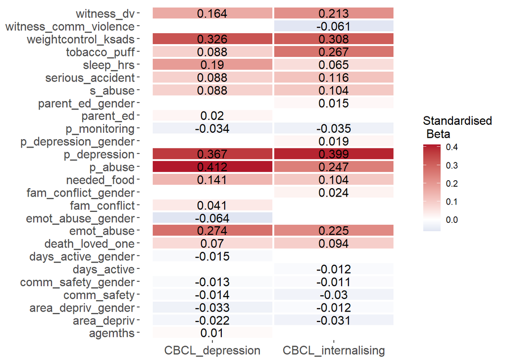

## beta.1se

### CBCL depression

|  | preds | beta.min | beta.1se | out |
| --- | --- | --- | --- | --- |
| 221 | p_depression | 0.367 | 0.338 | CBCL_depression |
| 310 | weightcontrol_ksads | 0.326 | 0.014 | CBCL_depression |
| 111 | sleep_hrs | 0.190 | 0.136 | CBCL_depression |
| 61 | witness_dv | 0.164 | 0.081 | CBCL_depression |
| 201 | fam_conflict | 0.041 | 0.004 | CBCL_depression |

### CBCL internalising

|  | preds | beta.min | beta.1se | out |
| --- | --- | --- | --- | --- |
| 22 | p_depression | 0.399 | 0.398 | CBCL_internalising |
| 3 | weightcontrol_ksads | 0.308 | 0.002 | CBCL_internalising |
| 6 | witness_dv | 0.213 | 0.123 | CBCL_internalising |
| 11 | sleep_hrs | 0.065 | 0.013 | CBCL_internalising |

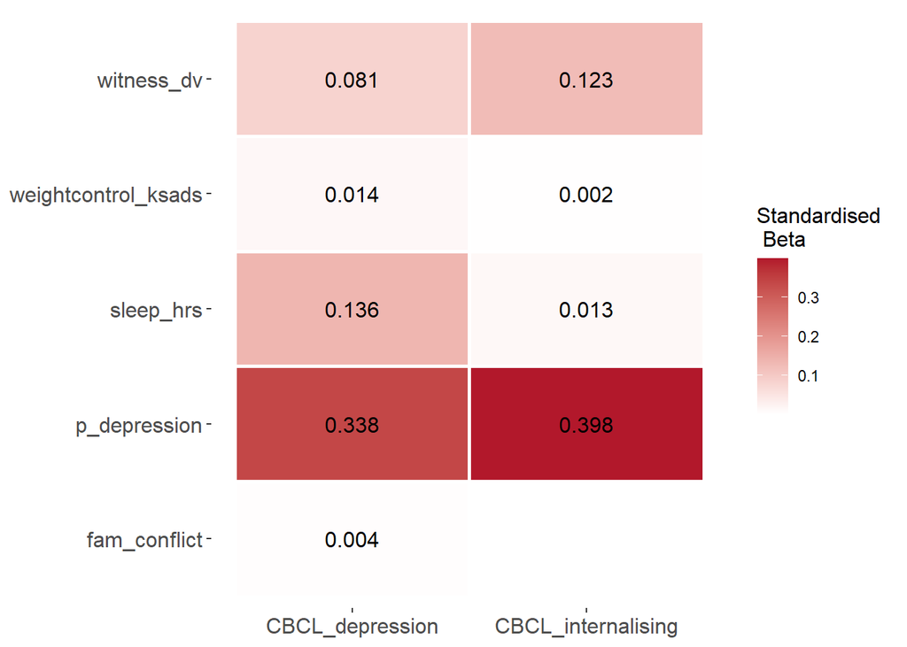

# Correlation plots

## Whole sample

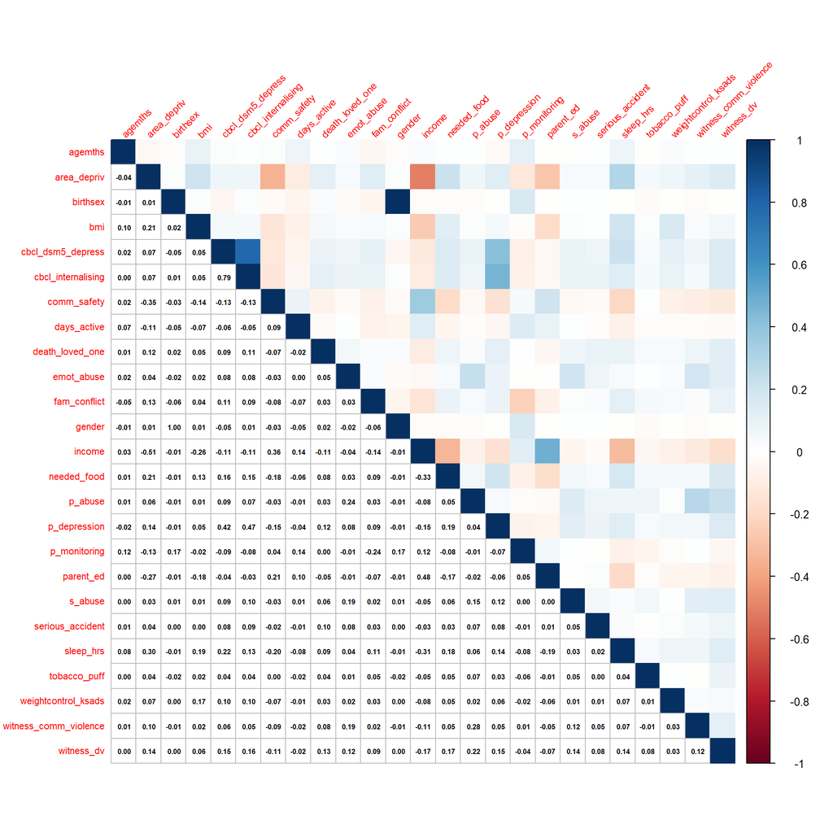

NULL

## Training sample

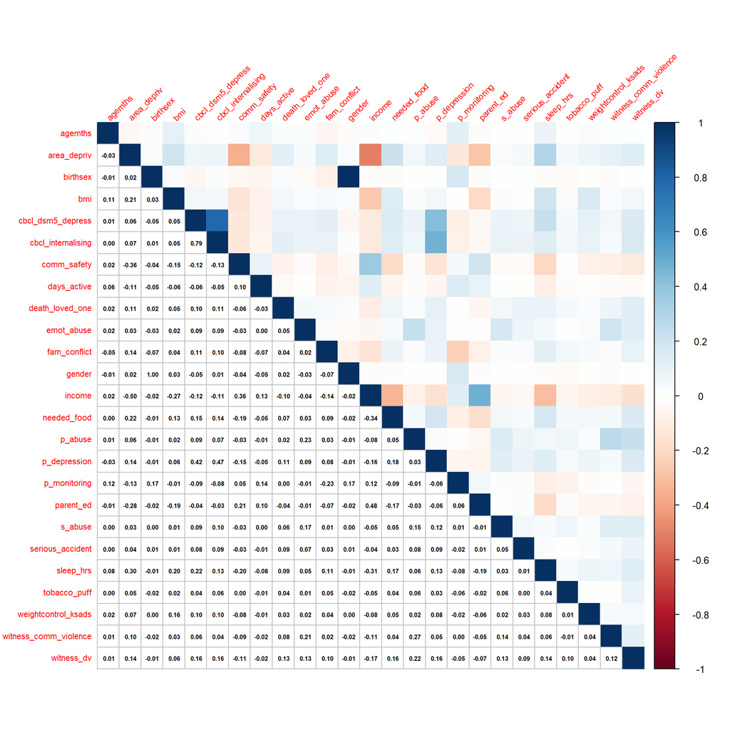

NULL

## Test sample

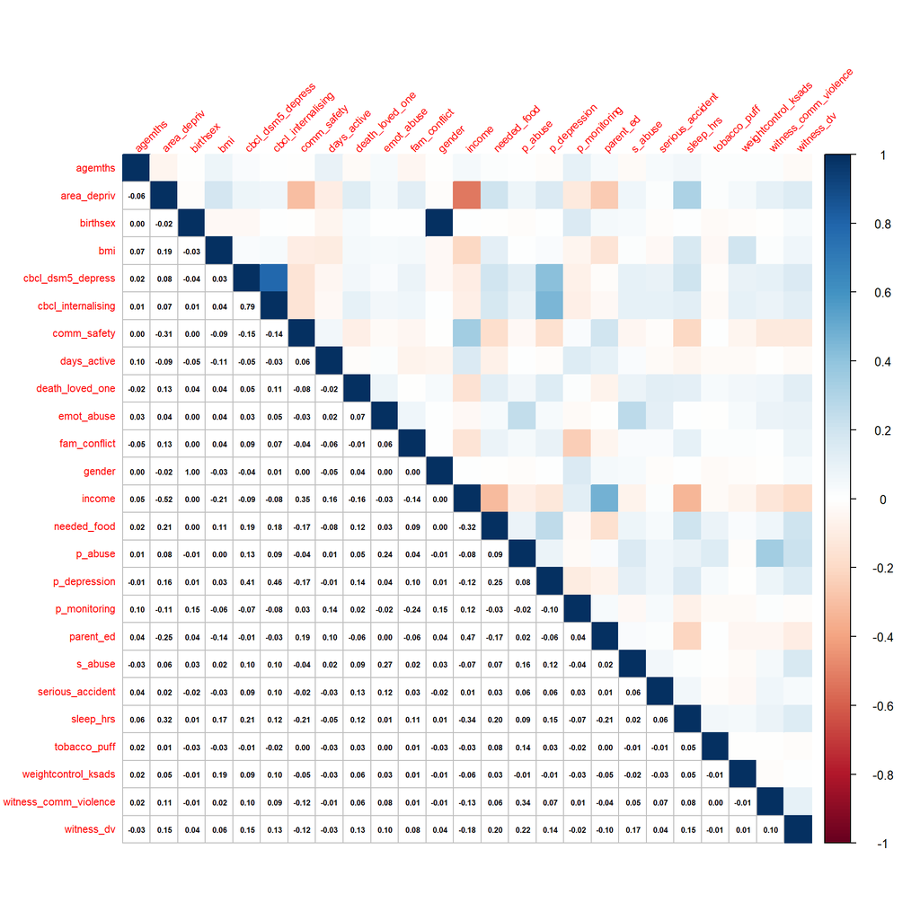

NULL

# Descriptives

## Whole sample

```
## temporary images written to 'C:\tmp'
```

Data Frame Summary

**Dimensions**: 7583 x 26  
**Duplicates**: 0

| **Variable** | **Stats / Values** | **Freqs (% of Valid)** | **Graph** | **Missing** |
| --- | --- | --- | --- | --- |
| tobacco_puff [factor] | 1. 0 2. 1 | 7529 ( 99.3% ) 54 ( 0.7% ) |  | 0 (0.0%) |
| weightcontrol_ksads [factor] | 1. 0 2. 1 | 7376 ( 97.3% ) 207 ( 2.7% ) |  | 0 (0.0%) |
| witness_comm_violence [factor] | 1. 0 2. 1 | 7515 ( 99.1% ) 68 ( 0.9% ) |  | 0 (0.0%) |
| death_loved_one [factor] | 1. 0 2. 1 | 5730 ( 75.6% ) 1853 ( 24.4% ) |  | 0 (0.0%) |
| witness_dv [factor] | 1. 0 2. 1 | 6971 ( 91.9% ) 612 ( 8.1% ) |  | 0 (0.0%) |
| s_abuse [factor] | 1. 0 2. 1 | 7427 ( 97.9% ) 156 ( 2.1% ) |  | 0 (0.0%) |
| p_abuse [factor] | 1. 0 2. 1 | 7511 ( 99.1% ) 72 ( 0.9% ) |  | 0 (0.0%) |
| emot_abuse [factor] | 1. 0 2. 1 | 7507 ( 99.0% ) 76 ( 1.0% ) |  | 0 (0.0%) |
| serious_accident [factor] | 1. 0 2. 1 | 6989 ( 92.2% ) 594 ( 7.8% ) |  | 0 (0.0%) |
| sleep_hrs [ordered, factor] | 1. 9+hrs 2. 8-9hrs 3. 7-8hrs 4. 5-7hrs 5. <5hrs | 3742 ( 49.3% ) 2747 ( 36.2% ) 867 ( 11.4% ) 207 ( 2.7% ) 20 ( 0.3% ) |  | 0 (0.0%) |
| bmi [numeric] | Mean (sd) : 18.7 (4.1) min ≤ med ≤ max: 9.8 ≤ 17.6 ≤ 53.9 IQR (CV) : 4.6 (0.2) | 5268 distinct values |  | 0 (0.0%) |
| needed_food [factor] | 1. 0 2. 1 | 7014 ( 92.5% ) 569 ( 7.5% ) |  | 0 (0.0%) |
| income [integer] | Mean (sd) : 7.3 (2.3) min ≤ med ≤ max: 1 ≤ 8 ≤ 10 IQR (CV) : 3 (0.3) | 1 : 239 ( 3.2% ) 2 : 279 ( 3.7% ) 3 : 181 ( 2.4% ) 4 : 331 ( 4.4% ) 5 : 443 ( 5.8% ) 6 : 653 ( 8.6% ) 7 : 1067 ( 14.1% ) 8 : 1129 ( 14.9% ) 9 : 2371 ( 31.3% ) 10 : 890 ( 11.7% ) |  | 0 (0.0%) |
| parent_ed [ordered, factor] | 1. less_HS 2. HS/GED 3. Some_College 4. Bachelor 5. Postgrad | 339 ( 4.5% ) 719 ( 9.5% ) 6009 ( 79.2% ) 234 ( 3.1% ) 282 ( 3.7% ) |  | 0 (0.0%) |
| birthsex [factor] | 1. M 2. F 3. Intersex | 4001 ( 52.8% ) 3582 ( 47.2% ) 0 ( 0.0% ) |  | 0 (0.0%) |
| gender [factor] | 1. M 2. F 3. GNC | 3998 ( 52.7% ) 3585 ( 47.3% ) 0 ( 0.0% ) |  | 0 (0.0%) |
| race_ethnicity [factor] | 1. White 2. Black 3. Hispanic 4. Asian 5. Other | 4214 ( 55.6% ) 963 ( 12.7% ) 1408 ( 18.6% ) 166 ( 2.2% ) 832 ( 11.0% ) |  | 0 (0.0%) |
| area_depriv [integer] | Mean (sd) : 38.8 (26.6) min ≤ med ≤ max: 1 ≤ 33 ≤ 100 IQR (CV) : 37 (0.7) | 100 distinct values |  | 0 (0.0%) |
| comm_safety [numeric] | Mean (sd) : 3.9 (0.9) min ≤ med ≤ max: 1 ≤ 4 ≤ 5 IQR (CV) : 1.3 (0.2) | 16 distinct values |  | 0 (0.0%) |
| days_active [integer] | Mean (sd) : 3.6 (2.3) min ≤ med ≤ max: 0 ≤ 3 ≤ 7 IQR (CV) : 3 (0.6) | 0 : 857 ( 11.3% ) 1 : 871 ( 11.5% ) 2 : 1024 ( 13.5% ) 3 : 1076 ( 14.2% ) 4 : 853 ( 11.2% ) 5 : 1050 ( 13.8% ) 6 : 558 ( 7.4% ) 7 : 1294 ( 17.1% ) |  | 0 (0.0%) |
| fam_conflict [numeric] | Mean (sd) : 2 (2) min ≤ med ≤ max: 0 ≤ 2 ≤ 9 IQR (CV) : 3 (1) | 11 distinct values |  | 0 (0.0%) |
| p_monitoring [numeric] | Mean (sd) : 4.4 (0.5) min ≤ med ≤ max: 1 ≤ 4.6 ≤ 5 IQR (CV) : 0.6 (0.1) | 19 distinct values |  | 0 (0.0%) |
| p_depression [integer] | Mean (sd) : 4 (3.6) min ≤ med ≤ max: 0 ≤ 3 ≤ 28 IQR (CV) : 5 (0.9) | 25 distinct values |  | 0 (0.0%) |
| agemths [integer] | Mean (sd) : 118.9 (7.4) min ≤ med ≤ max: 107 ≤ 119 ≤ 132 IQR (CV) : 13 (0.1) | 26 distinct values |  | 0 (0.0%) |
| cbcl_internalising [integer] | Mean (sd) : 5.1 (5.5) min ≤ med ≤ max: 0 ≤ 3 ≤ 51 IQR (CV) : 6 (1.1) | 40 distinct values |  | 0 (0.0%) |
| cbcl_dsm5_depress [integer] | Mean (sd) : 1.3 (2) min ≤ med ≤ max: 0 ≤ 0 ≤ 17 IQR (CV) : 2 (1.6) | 18 distinct values |  | 0 (0.0%) |

Generated by summarytools 1.0.1 ([R](https://www.r-project.org/) version 4.4.1)  
2024-10-30

## Training sample

```
## temporary images written to 'C:\tmp'
```

Data Frame Summary

train

**Dimensions**: 6046 x 26  
**Duplicates**: 0

| **Variable** | **Stats / Values** | **Freqs (% of Valid)** | **Graph** | **Missing** |
| --- | --- | --- | --- | --- |
| tobacco_puff [factor] | 1. 0 2. 1 | 5996 ( 99.2% ) 50 ( 0.8% ) |  | 0 (0.0%) |
| weightcontrol_ksads [factor] | 1. 0 2. 1 | 5880 ( 97.3% ) 166 ( 2.7% ) |  | 0 (0.0%) |
| witness_comm_violence [factor] | 1. 0 2. 1 | 5989 ( 99.1% ) 57 ( 0.9% ) |  | 0 (0.0%) |
| death_loved_one [factor] | 1. 0 2. 1 | 4558 ( 75.4% ) 1488 ( 24.6% ) |  | 0 (0.0%) |
| witness_dv [factor] | 1. 0 2. 1 | 5534 ( 91.5% ) 512 ( 8.5% ) |  | 0 (0.0%) |
| s_abuse [factor] | 1. 0 2. 1 | 5917 ( 97.9% ) 129 ( 2.1% ) |  | 0 (0.0%) |
| p_abuse [factor] | 1. 0 2. 1 | 5986 ( 99.0% ) 60 ( 1.0% ) |  | 0 (0.0%) |
| emot_abuse [factor] | 1. 0 2. 1 | 5982 ( 98.9% ) 64 ( 1.1% ) |  | 0 (0.0%) |
| serious_accident [factor] | 1. 0 2. 1 | 5564 ( 92.0% ) 482 ( 8.0% ) |  | 0 (0.0%) |
| sleep_hrs [ordered, factor] | 1. 9+hrs 2. 8-9hrs 3. 7-8hrs 4. 5-7hrs 5. <5hrs | 2971 ( 49.1% ) 2204 ( 36.5% ) 683 ( 11.3% ) 174 ( 2.9% ) 14 ( 0.2% ) |  | 0 (0.0%) |
| bmi [numeric] | Mean (sd) : 18.8 (4.1) min ≤ med ≤ max: 10 ≤ 17.6 ≤ 53.9 IQR (CV) : 4.6 (0.2) | 4383 distinct values |  | 0 (0.0%) |
| needed_food [factor] | 1. 0 2. 1 | 5594 ( 92.5% ) 452 ( 7.5% ) |  | 0 (0.0%) |
| income [integer] | Mean (sd) : 7.3 (2.4) min ≤ med ≤ max: 1 ≤ 8 ≤ 10 IQR (CV) : 3 (0.3) | 1 : 196 ( 3.2% ) 2 : 232 ( 3.8% ) 3 : 145 ( 2.4% ) 4 : 264 ( 4.4% ) 5 : 349 ( 5.8% ) 6 : 519 ( 8.6% ) 7 : 868 ( 14.4% ) 8 : 904 ( 15.0% ) 9 : 1861 ( 30.8% ) 10 : 708 ( 11.7% ) |  | 0 (0.0%) |
| parent_ed [ordered, factor] | 1. less_HS 2. HS/GED 3. Some_College 4. Bachelor 5. Postgrad | 276 ( 4.6% ) 600 ( 9.9% ) 4758 ( 78.7% ) 179 ( 3.0% ) 233 ( 3.9% ) |  | 0 (0.0%) |
| birthsex [factor] | 1. M 2. F 3. Intersex | 3232 ( 53.5% ) 2814 ( 46.5% ) 0 ( 0.0% ) |  | 0 (0.0%) |
| gender [factor] | 1. M 2. F 3. GNC | 3229 ( 53.4% ) 2817 ( 46.6% ) 0 ( 0.0% ) |  | 0 (0.0%) |
| race_ethnicity [factor] | 1. White 2. Black 3. Hispanic 4. Asian 5. Other | 3339 ( 55.2% ) 759 ( 12.6% ) 1134 ( 18.8% ) 132 ( 2.2% ) 682 ( 11.3% ) |  | 0 (0.0%) |
| area_depriv [integer] | Mean (sd) : 38.9 (26.5) min ≤ med ≤ max: 1 ≤ 33 ≤ 100 IQR (CV) : 36 (0.7) | 100 distinct values |  | 0 (0.0%) |
| comm_safety [numeric] | Mean (sd) : 3.9 (0.9) min ≤ med ≤ max: 1 ≤ 4 ≤ 5 IQR (CV) : 1.3 (0.2) | 15 distinct values |  | 0 (0.0%) |
| days_active [integer] | Mean (sd) : 3.6 (2.3) min ≤ med ≤ max: 0 ≤ 3 ≤ 7 IQR (CV) : 3 (0.6) | 0 : 672 ( 11.1% ) 1 : 701 ( 11.6% ) 2 : 818 ( 13.5% ) 3 : 860 ( 14.2% ) 4 : 670 ( 11.1% ) 5 : 843 ( 13.9% ) 6 : 455 ( 7.5% ) 7 : 1027 ( 17.0% ) |  | 0 (0.0%) |
| fam_conflict [numeric] | Mean (sd) : 2 (2) min ≤ med ≤ max: 0 ≤ 2 ≤ 9 IQR (CV) : 3 (1) | 11 distinct values |  | 0 (0.0%) |
| p_monitoring [numeric] | Mean (sd) : 4.4 (0.5) min ≤ med ≤ max: 1.8 ≤ 4.6 ≤ 5 IQR (CV) : 0.6 (0.1) | 18 distinct values |  | 0 (0.0%) |
| p_depression [integer] | Mean (sd) : 4.1 (3.7) min ≤ med ≤ max: 0 ≤ 3 ≤ 28 IQR (CV) : 5 (0.9) | 25 distinct values |  | 0 (0.0%) |
| agemths [integer] | Mean (sd) : 118.9 (7.4) min ≤ med ≤ max: 107 ≤ 119 ≤ 132 IQR (CV) : 13 (0.1) | 26 distinct values |  | 0 (0.0%) |
| cbcl_internalising [integer] | Mean (sd) : 5.1 (5.5) min ≤ med ≤ max: 0 ≤ 3 ≤ 51 IQR (CV) : 6 (1.1) | 39 distinct values |  | 0 (0.0%) |
| cbcl_dsm5_depress [integer] | Mean (sd) : 1.3 (2) min ≤ med ≤ max: 0 ≤ 0 ≤ 16 IQR (CV) : 2 (1.5) | 17 distinct values |  | 0 (0.0%) |

Generated by summarytools 1.0.1 ([R](https://www.r-project.org/) version 4.4.1)  
2024-10-30

## Test sample

```
## temporary images written to 'C:\tmp'
```

Data Frame Summary

test

**Dimensions**: 1537 x 26  
**Duplicates**: 0

| **Variable** | **Stats / Values** | **Freqs (% of Valid)** | **Graph** | **Missing** |
| --- | --- | --- | --- | --- |
| tobacco_puff [factor] | 1. 0 2. 1 | 1533 ( 99.7% ) 4 ( 0.3% ) |  | 0 (0.0%) |
| weightcontrol_ksads [factor] | 1. 0 2. 1 | 1496 ( 97.3% ) 41 ( 2.7% ) |  | 0 (0.0%) |
| witness_comm_violence [factor] | 1. 0 2. 1 | 1526 ( 99.3% ) 11 ( 0.7% ) |  | 0 (0.0%) |
| death_loved_one [factor] | 1. 0 2. 1 | 1172 ( 76.3% ) 365 ( 23.7% ) |  | 0 (0.0%) |
| witness_dv [factor] | 1. 0 2. 1 | 1437 ( 93.5% ) 100 ( 6.5% ) |  | 0 (0.0%) |
| s_abuse [factor] | 1. 0 2. 1 | 1510 ( 98.2% ) 27 ( 1.8% ) |  | 0 (0.0%) |
| p_abuse [factor] | 1. 0 2. 1 | 1525 ( 99.2% ) 12 ( 0.8% ) |  | 0 (0.0%) |
| emot_abuse [factor] | 1. 0 2. 1 | 1525 ( 99.2% ) 12 ( 0.8% ) |  | 0 (0.0%) |
| serious_accident [factor] | 1. 0 2. 1 | 1425 ( 92.7% ) 112 ( 7.3% ) |  | 0 (0.0%) |
| sleep_hrs [ordered, factor] | 1. 9+hrs 2. 8-9hrs 3. 7-8hrs 4. 5-7hrs 5. <5hrs | 771 ( 50.2% ) 543 ( 35.3% ) 184 ( 12.0% ) 33 ( 2.1% ) 6 ( 0.4% ) |  | 0 (0.0%) |
| bmi [numeric] | Mean (sd) : 18.6 (4) min ≤ med ≤ max: 9.8 ≤ 17.5 ≤ 45.6 IQR (CV) : 4.4 (0.2) | 1346 distinct values |  | 0 (0.0%) |
| needed_food [factor] | 1. 0 2. 1 | 1420 ( 92.4% ) 117 ( 7.6% ) |  | 0 (0.0%) |
| income [integer] | Mean (sd) : 7.4 (2.3) min ≤ med ≤ max: 1 ≤ 8 ≤ 10 IQR (CV) : 3 (0.3) | 1 : 43 ( 2.8% ) 2 : 47 ( 3.1% ) 3 : 36 ( 2.3% ) 4 : 67 ( 4.4% ) 5 : 94 ( 6.1% ) 6 : 134 ( 8.7% ) 7 : 199 ( 12.9% ) 8 : 225 ( 14.6% ) 9 : 510 ( 33.2% ) 10 : 182 ( 11.8% ) |  | 0 (0.0%) |
| parent_ed [ordered, factor] | 1. less_HS 2. HS/GED 3. Some_College 4. Bachelor 5. Postgrad | 63 ( 4.1% ) 119 ( 7.7% ) 1251 ( 81.4% ) 55 ( 3.6% ) 49 ( 3.2% ) |  | 0 (0.0%) |
| birthsex [factor] | 1. M 2. F 3. Intersex | 769 ( 50.0% ) 768 ( 50.0% ) 0 ( 0.0% ) |  | 0 (0.0%) |
| gender [factor] | 1. M 2. F 3. GNC | 769 ( 50.0% ) 768 ( 50.0% ) 0 ( 0.0% ) |  | 0 (0.0%) |
| race_ethnicity [factor] | 1. White 2. Black 3. Hispanic 4. Asian 5. Other | 875 ( 56.9% ) 204 ( 13.3% ) 274 ( 17.8% ) 34 ( 2.2% ) 150 ( 9.8% ) |  | 0 (0.0%) |
| area_depriv [integer] | Mean (sd) : 38.7 (26.9) min ≤ med ≤ max: 1 ≤ 32 ≤ 100 IQR (CV) : 39 (0.7) | 100 distinct values |  | 0 (0.0%) |
| comm_safety [numeric] | Mean (sd) : 3.9 (1) min ≤ med ≤ max: 1 ≤ 4 ≤ 5 IQR (CV) : 1.3 (0.2) | 15 distinct values |  | 0 (0.0%) |
| days_active [integer] | Mean (sd) : 3.6 (2.3) min ≤ med ≤ max: 0 ≤ 3 ≤ 7 IQR (CV) : 3 (0.7) | 0 : 185 ( 12.0% ) 1 : 170 ( 11.1% ) 2 : 206 ( 13.4% ) 3 : 216 ( 14.1% ) 4 : 183 ( 11.9% ) 5 : 207 ( 13.5% ) 6 : 103 ( 6.7% ) 7 : 267 ( 17.4% ) |  | 0 (0.0%) |
| fam_conflict [numeric] | Mean (sd) : 2 (1.9) min ≤ med ≤ max: 0 ≤ 1 ≤ 9 IQR (CV) : 3 (1) | 0 : 420 ( 27.3% ) 1 : 354 ( 23.0% ) 2 : 265 ( 17.2% ) 3 : 178 ( 11.6% ) 4 : 127 ( 8.3% ) 5 : 97 ( 6.3% ) 6 : 51 ( 3.3% ) 7 : 36 ( 2.3% ) 8 : 8 ( 0.5% ) 9 : 1 ( 0.1% ) |  | 0 (0.0%) |
| p_monitoring [numeric] | Mean (sd) : 4.4 (0.5) min ≤ med ≤ max: 1 ≤ 4.4 ≤ 5 IQR (CV) : 0.6 (0.1) | 16 distinct values |  | 0 (0.0%) |
| p_depression [integer] | Mean (sd) : 3.9 (3.5) min ≤ med ≤ max: 0 ≤ 3 ≤ 21 IQR (CV) : 5 (0.9) | 21 distinct values |  | 0 (0.0%) |
| agemths [integer] | Mean (sd) : 119.2 (7.5) min ≤ med ≤ max: 107 ≤ 119 ≤ 132 IQR (CV) : 14 (0.1) | 26 distinct values |  | 0 (0.0%) |
| cbcl_internalising [integer] | Mean (sd) : 5.1 (5.5) min ≤ med ≤ max: 0 ≤ 3 ≤ 37 IQR (CV) : 6 (1.1) | 36 distinct values |  | 0 (0.0%) |
| cbcl_dsm5_depress [integer] | Mean (sd) : 1.3 (2) min ≤ med ≤ max: 0 ≤ 0 ≤ 17 IQR (CV) : 2 (1.6) | 16 distinct values |  | 0 (0.0%) |

Generated by summarytools 1.0.1 ([R](https://www.r-project.org/) version 4.4.1)  
2024-10-30

# Sensitivity analyses using birthsex instead of gender

# CBCL DSM5-oriented depression subscale

## Lambda plot

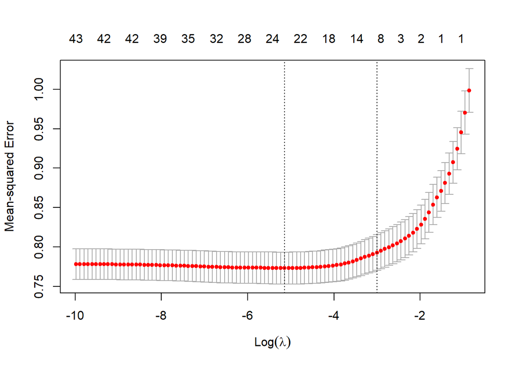

## Fit statistics

| Sample | Lambda | MSE | RMSE | MAE |
| --- | --- | --- | --- | --- |
| training | min | 0.766 | 0.875 | 0.599 |
| training | 1se | 0.789 | 0.888 | 0.611 |
| test | min | 0.782 | 0.884 | 0.590 |
| test | 1se | 0.782 | 0.884 | 0.590 |

## Plot predictions

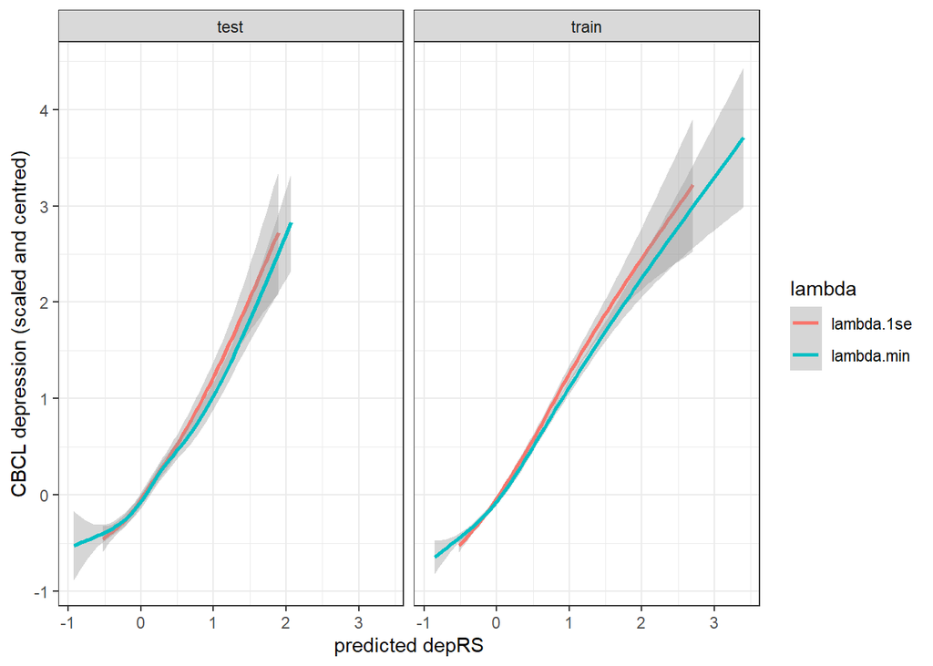

# CBCL internalising subscale

## Lambda plot

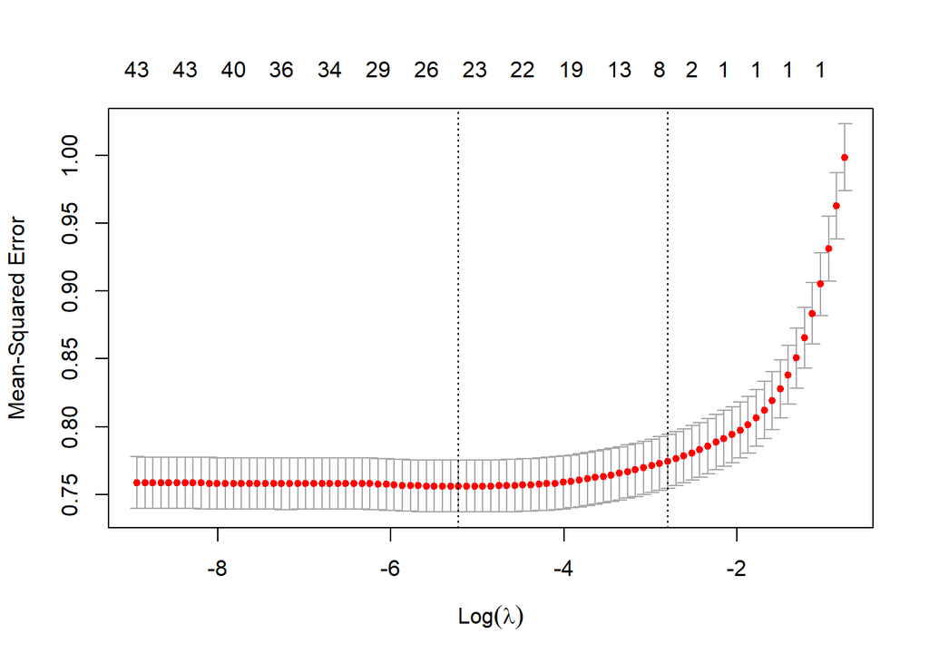

## Fit statistics

| Sample | Lambda | MSE | RMSE | MAE |
| --- | --- | --- | --- | --- |
| training | min | 0.746 | 0.864 | 0.627 |
| training | 1se | 0.772 | 0.879 | 0.639 |
| test | min | 0.800 | 0.894 | 0.595 |
| test | 1se | 0.800 | 0.894 | 0.595 |

## Plot predictions

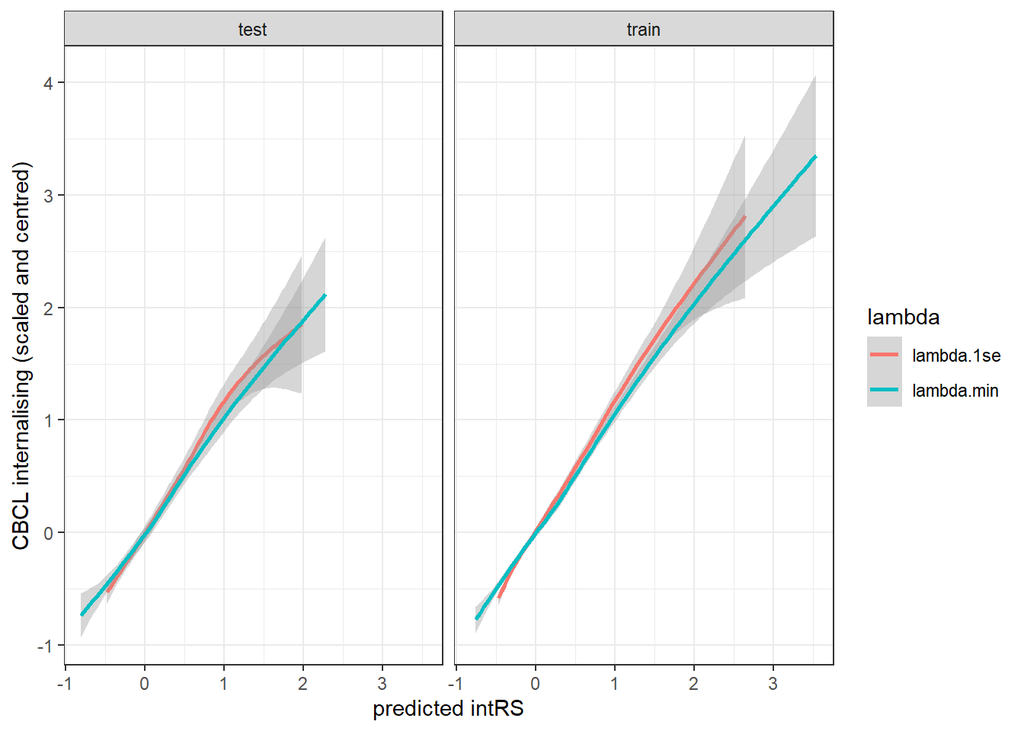

# Non-zero coefficients

beta.min = coefficients for lambda value that produces minimum mean cross-validated error beta.1se = coefficients for lambda value that produces the most regularized model while keeping the cross-validated error within one standard error of the minimum.

| predictor | dep_beta.min | dep_beta.1se | int_beta.min | int_beta.1se |
| --- | --- | --- | --- | --- |
| (Intercept) | -1.979 | -0.620 | -1.806 | -0.220 |
| tobacco_puff | 0.083 | 0.000 | 0.250 | 0.000 |
| weightcontrol_ksads | 0.323 | 0.094 | 0.297 | 0.032 |
| witness_comm_violence | 0.000 | 0.000 | -0.035 | 0.000 |
| death_loved_one | 0.070 | 0.000 | 0.092 | 0.000 |
| witness_dv | 0.166 | 0.111 | 0.215 | 0.143 |
| s_abuse | 0.085 | 0.000 | 0.095 | 0.000 |
| p_abuse | 0.407 | 0.123 | 0.229 | 0.000 |
| emot_abuse | 0.269 | 0.000 | 0.211 | 0.000 |
| serious_accident | 0.086 | 0.000 | 0.110 | 0.000 |
| sleep_hrs | 0.190 | 0.147 | 0.062 | 0.019 |
| bmi | -0.003 | 0.000 | 0.000 | 0.000 |
| needed_food | 0.140 | 0.028 | 0.097 | 0.000 |
| income | 0.000 | 0.000 | 0.000 | 0.000 |
| parent_ed | 0.019 | 0.000 | 0.000 | 0.000 |
| birthsex | 0.000 | 0.000 | 0.000 | 0.000 |
| area_depriv | -0.022 | 0.000 | -0.030 | 0.000 |
| comm_safety | -0.013 | 0.000 | -0.029 | -0.001 |
| days_active | 0.000 | 0.000 | -0.011 | 0.000 |
| fam_conflict | 0.040 | 0.015 | 0.000 | 0.000 |
| p_monitoring | -0.035 | -0.005 | -0.034 | 0.000 |
| p_depression | 0.367 | 0.347 | 0.402 | 0.402 |
| agemths | 0.009 | 0.000 | 0.000 | 0.000 |
| tobacco_puff_sex | 0.000 | 0.000 | 0.000 | 0.000 |
| weightcontrol_ksads_sex | 0.000 | 0.000 | 0.007 | 0.000 |
| witness_comm_violence_sex | 0.000 | 0.000 | 0.000 | 0.000 |
| death_loved_one_sex | 0.000 | 0.000 | 0.000 | 0.000 |
| witness_dv_sex | 0.000 | 0.000 | 0.000 | 0.000 |
| s_abuse_sex | 0.000 | 0.000 | 0.000 | 0.000 |
| p_abuse_sex | 0.000 | 0.000 | 0.000 | 0.000 |
| emot_abuse_sex | -0.062 | 0.000 | 0.000 | 0.000 |
| serious_accident_sex | 0.000 | 0.000 | 0.000 | 0.000 |
| sleep_hrs_sex | 0.000 | 0.000 | 0.000 | 0.000 |
| bmi_sex | 0.000 | 0.000 | 0.000 | 0.000 |
| needed_food_sex | 0.000 | 0.000 | 0.000 | 0.000 |
| income_sex | 0.000 | 0.000 | 0.000 | 0.000 |
| parent_ed_sex | 0.000 | 0.000 | 0.013 | 0.000 |
| area_depriv_sex | -0.033 | 0.000 | -0.010 | 0.000 |
| comm_safety_sex | -0.013 | 0.000 | -0.010 | 0.000 |
| days_active_sex | -0.015 | 0.000 | 0.000 | 0.000 |
| fam_conflict_sex | 0.001 | 0.000 | 0.022 | 0.000 |
| p_monitoring_sex | 0.000 | 0.000 | 0.000 | 0.000 |
| p_depression_sex | 0.000 | 0.000 | 0.016 | 0.000 |
| agemths_sex | 0.000 | 0.000 | 0.004 | 0.000 |

## beta.min

### CBCL depression

|  | preds | beta.min | beta.1se | out |
| --- | --- | --- | --- | --- |
| 81 | p_abuse | 0.407 | 0.123 | CBCL_depression |
| 221 | p_depression | 0.367 | 0.347 | CBCL_depression |
| 310 | weightcontrol_ksads | 0.323 | 0.094 | CBCL_depression |
| 91 | emot_abuse | 0.269 | 0.000 | CBCL_depression |
| 111 | sleep_hrs | 0.190 | 0.147 | CBCL_depression |
| 61 | witness_dv | 0.166 | 0.111 | CBCL_depression |
| 131 | needed_food | 0.140 | 0.028 | CBCL_depression |
| 101 | serious_accident | 0.086 | 0.000 | CBCL_depression |
| 71 | s_abuse | 0.085 | 0.000 | CBCL_depression |
| 210 | tobacco_puff | 0.083 | 0.000 | CBCL_depression |
| 51 | death_loved_one | 0.070 | 0.000 | CBCL_depression |
| 201 | fam_conflict | 0.040 | 0.015 | CBCL_depression |
| 151 | parent_ed | 0.019 | 0.000 | CBCL_depression |
| 231 | agemths | 0.009 | 0.000 | CBCL_depression |
| 411 | fam_conflict_sex | 0.001 | 0.000 | CBCL_depression |
| 121 | bmi | -0.003 | 0.000 | CBCL_depression |
| 181 | comm_safety | -0.013 | 0.000 | CBCL_depression |
| 391 | comm_safety_sex | -0.013 | 0.000 | CBCL_depression |
| 401 | days_active_sex | -0.015 | 0.000 | CBCL_depression |
| 171 | area_depriv | -0.022 | 0.000 | CBCL_depression |
| 381 | area_depriv_sex | -0.033 | 0.000 | CBCL_depression |
| 211 | p_monitoring | -0.035 | -0.005 | CBCL_depression |
| 311 | emot_abuse_sex | -0.062 | 0.000 | CBCL_depression |

### CBCL internalising

|  | preds | beta.min | beta.1se | out |
| --- | --- | --- | --- | --- |
| 22 | p_depression | 0.402 | 0.402 | CBCL_internalising |
| 3 | weightcontrol_ksads | 0.297 | 0.032 | CBCL_internalising |
| 2 | tobacco_puff | 0.250 | 0.000 | CBCL_internalising |
| 8 | p_abuse | 0.229 | 0.000 | CBCL_internalising |
| 6 | witness_dv | 0.215 | 0.143 | CBCL_internalising |
| 9 | emot_abuse | 0.211 | 0.000 | CBCL_internalising |
| 10 | serious_accident | 0.110 | 0.000 | CBCL_internalising |
| 13 | needed_food | 0.097 | 0.000 | CBCL_internalising |
| 7 | s_abuse | 0.095 | 0.000 | CBCL_internalising |
| 5 | death_loved_one | 0.092 | 0.000 | CBCL_internalising |
| 11 | sleep_hrs | 0.062 | 0.019 | CBCL_internalising |
| 41 | fam_conflict_sex | 0.022 | 0.000 | CBCL_internalising |
| 43 | p_depression_sex | 0.016 | 0.000 | CBCL_internalising |
| 37 | parent_ed_sex | 0.013 | 0.000 | CBCL_internalising |
| 25 | weightcontrol_ksads_sex | 0.007 | 0.000 | CBCL_internalising |
| 44 | agemths_sex | 0.004 | 0.000 | CBCL_internalising |
| 38 | area_depriv_sex | -0.010 | 0.000 | CBCL_internalising |
| 39 | comm_safety_sex | -0.010 | 0.000 | CBCL_internalising |
| 19 | days_active | -0.011 | 0.000 | CBCL_internalising |
| 18 | comm_safety | -0.029 | -0.001 | CBCL_internalising |
| 17 | area_depriv | -0.030 | 0.000 | CBCL_internalising |
| 21 | p_monitoring | -0.034 | 0.000 | CBCL_internalising |
| 4 | witness_comm_violence | -0.035 | 0.000 | CBCL_internalising |

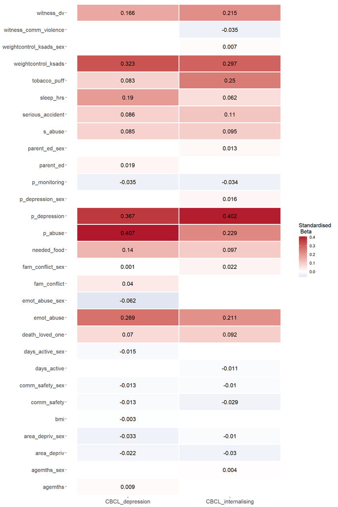

## beta.1se

### CBCL depression

|  | preds | beta.min | beta.1se | out |
| --- | --- | --- | --- | --- |
| 81 | p_abuse | 0.407 | 0.123 | CBCL_depression |
| 221 | p_depression | 0.367 | 0.347 | CBCL_depression |
| 310 | weightcontrol_ksads | 0.323 | 0.094 | CBCL_depression |
| 111 | sleep_hrs | 0.190 | 0.147 | CBCL_depression |
| 61 | witness_dv | 0.166 | 0.111 | CBCL_depression |
| 131 | needed_food | 0.140 | 0.028 | CBCL_depression |
| 201 | fam_conflict | 0.040 | 0.015 | CBCL_depression |
| 211 | p_monitoring | -0.035 | -0.005 | CBCL_depression |

### CBCL internalising

|  | preds | beta.min | beta.1se | out |
| --- | --- | --- | --- | --- |
| 22 | p_depression | 0.402 | 0.402 | CBCL_internalising |
| 3 | weightcontrol_ksads | 0.297 | 0.032 | CBCL_internalising |
| 6 | witness_dv | 0.215 | 0.143 | CBCL_internalising |
| 11 | sleep_hrs | 0.062 | 0.019 | CBCL_internalising |
| 18 | comm_safety | -0.029 | -0.001 | CBCL_internalising |

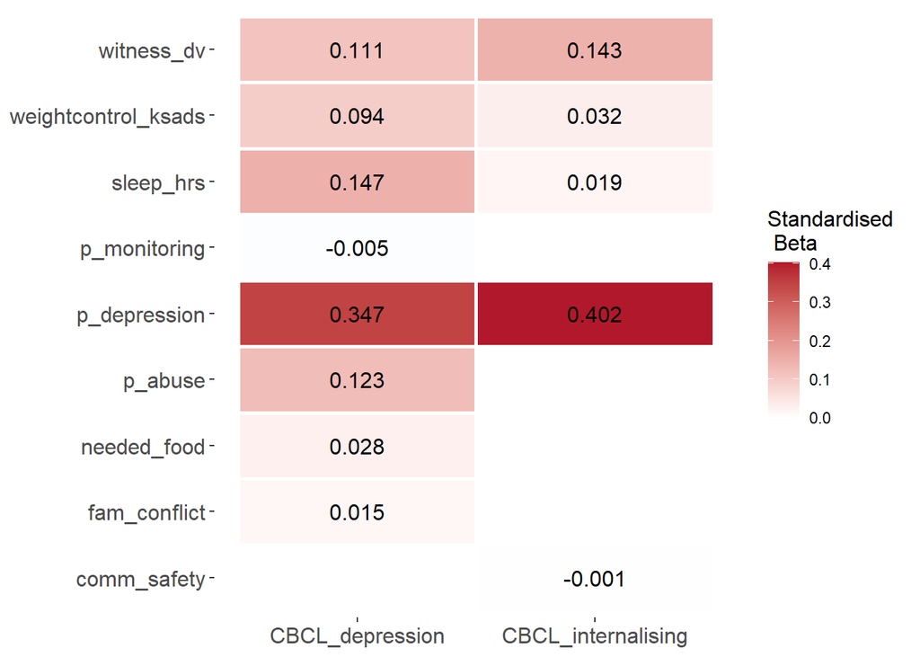